# What are Networks?

## What is a network?

- A set of entities
  - **Nodes**, **Vertices**
- Joined via a set of relations
  - **Links**, **Ties**, **Edges**
- In a **point and line plot**:
  - Entities are some shape (e.g., circles)
  - Relations are lines

## What is a network?

- Don’t confuse pictures of networks with the real thing!
- In a **point and line plot**:
  - Entities are some shape (e.g., circles)
  - Relations are lines

## What is a network?

- Lots of things in the world are networks

[interactive chart not shown]

## U.S. Airport Network

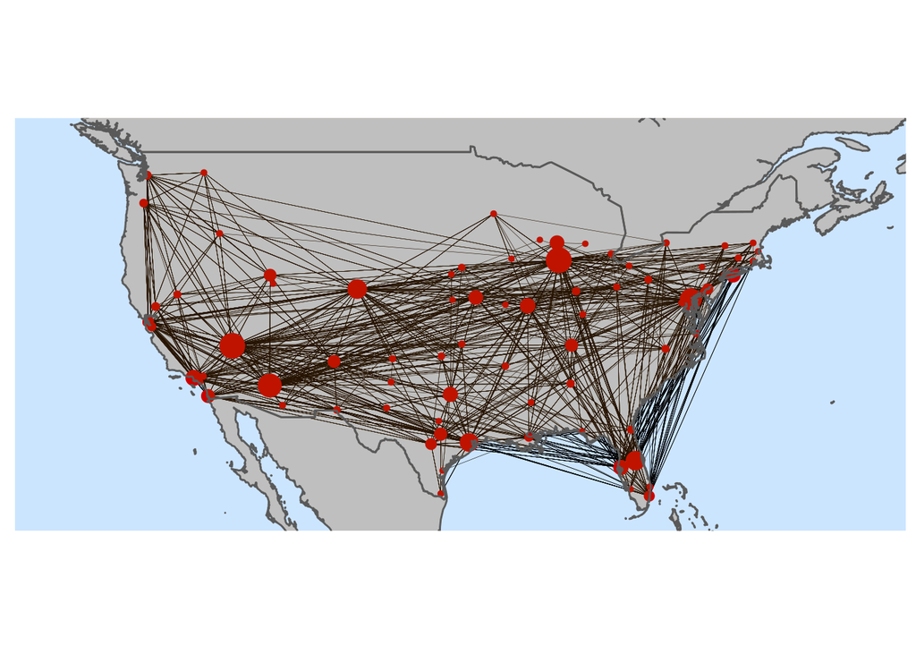

## GoT’s Social Network

[figure not shown]

## The Brain’s Neural Network

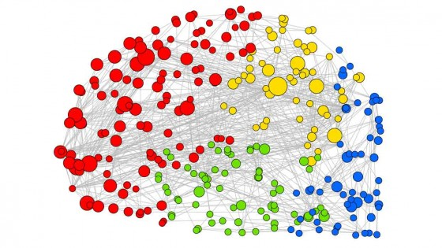

## The Network of Psychological Symptoms

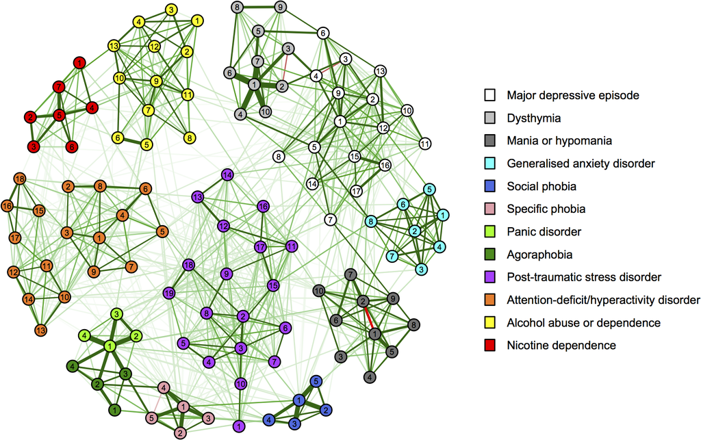

## The Body’s Organ Network

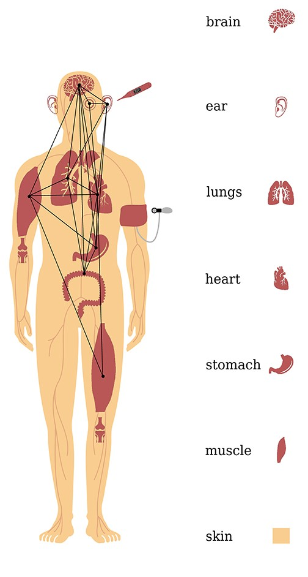

## Defining Social Networks

- Networks are everywhere, but only a specific subset of them is actually a social network.
- A network is **“social”** if it involves people (or groups) and their thoughts, interactions, and behaviors.
- Even when we connect through technology (like texting or flying), it is the human interaction that makes it a social network.
- In this class, we focus on the “purely social” elements: relationships, feelings, and how people exchange things.

## What is a social network?

- Some networks are social networks
  - Schools, Workplaces, Instagram
- Social networks link people via social relations

## What is a social network?

- Some networks are both social and technological
  - Instagram, The WWW, Airports
- Some networks are “purely” social
  - Schools, Workplaces

In this quarter we will learn about **social network analysis (SNA)**. We will look mostly at “pure” social networks.

## The Roots of Social Network Analysis (SNA)

- **Social Network Analysis (SNA)** is the main way we study these connections.
- It grew primarily in the field of sociology, starting in the 1970s.
- Today it is a team effort across different sciences, drawing on insights from multiple disciplines:
  - Sociology
  - Psychology
  - Anthropology
  - Communication

## What is a social network analysis?

- SNA is an interdisciplinary field in social science in charge of studying social networks.

[interactive chart not shown]

## The Big Picture: Network Science

- SNA is just one branch of a much larger tree called **Network Science**.
- Network Science studies all kinds of networks in the world.
- This broader field includes experts from physics, computer science, biology, data science, and math.

## The Big Picture: Network Science

[interactive chart not shown]

## Summary

- **Networks:** Systems of entities linked by relations
  - Different kinds: Social, biological, technological, etc.
- **Social Networks:** Systems of interactive people (or groups of people) linked by social relations
- **Network Science:** Interdisciplinary field in charge of studying all types of networks
  - Biology, mathematics, computer science, physics, etc.
- **Social Network Analysis:** Interdisciplinary field in charge of studying social networks
  - Sociology, psychology, anthropology, communication

## The two faces of Social Network Analysis

- SNA has two main faces; the first is **Network Theory**.
- **Network Theory** explains how networks work and what they do to the people inside them.
- It tries to answer big questions: Why do people connect? How do they behave? What are the consequences?
- A great example is “social capital”—the idea that who you know brings you real-world benefits.

## The two faces of Social Network Analysis

- The second side of SNA is **Network Measurement**.
- This is where we use math and numbers to measure network properties.
- Math helps us take “fuzzy” social concepts—like “popularity” or “social position”—and turn them into precise, measurable quantities.
- These numbers allow us to predict why some people, companies, or countries succeed while others do not.

## The two faces of social network analysis

[interactive chart not shown]

- **Theory:** General statements about how people behave in networks.
- **Measurement:** Helps make natural language concepts more precise.

## Two mathematical representations of networks

- Social Networks can be mathematically represented in two ways
- We will learn how to go back and forth between the two:
  1. A “Matrix”
  2. A “Graph”

## Levels of Analysis in social networks

[interactive chart not shown]

*We will be working through all these levels in the course! (But not in this order)*

## Zooming In: Micro Levels of Analysis

- We can study networks by zooming in very closely.
- **The Individual (Node) Level:** We examine a single person and their personal connections, collectively known as their **“ego network”**.
- **Small Configurations (Dyad/Triad Level):** We look at relationships between two or three people.
  - At this level, we study things like how strong a tie is, or how small groups balance their friendships.

## Zooming Out: Macro Levels of Analysis

- **Communities (Subgroups):** We look at larger clusters of people to see how close-knit they are.
- **The Whole Network:** We look at the entire system to find large-scale trends, like whether the network is a “Small World”.

## Three ways of talking about “social networks”

- **Social network theory** is a branch of social science that uses natural language and intuition to describe real-world human interactions.
  - Its concepts can be vague.
- **Graph theory** is a branch of pure mathematics that uses less ambiguous terms to define “analogues” of these fuzzy social network concepts.
- **Matrix algebra** is a branch of applied mathematics that links graph theory concepts to allow for calculations and the development of metrics for social network ideas (like “centrality”).

## The “Three-Step Shuffle”

- A major goal of learning SNA is mastering three different ways to view networks:
  1. Seeing networks as real-world human interactions.
  2. Seeing networks as mathematical graphs.
  3. Seeing networks as quantitative data tables (matrices).
- Transitioning smoothly between these three views is the key to understanding how networks work and change.

## The “Three-Step Shuffle”

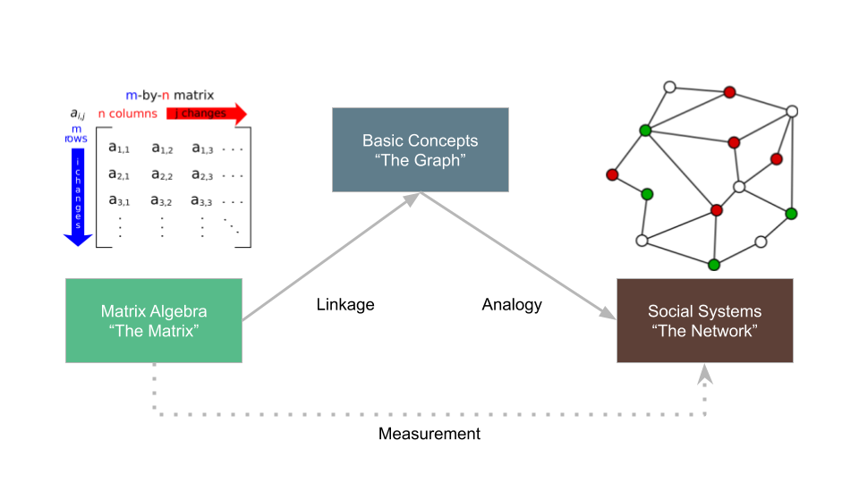